# RPC-PI Experiment - Proportion and Paired Inference

2026-07-04

# 1 Objetivo

Este R Markdown faz inferencia estatistica baseada em **proporcoes** e em **comparacoes pareadas contra C0**.

Ele e diferente do `07_seed_confidence_intervals.Rmd`:

- o Rmd 07 usa **seed/run** como unidade estatistica;
- este Rmd usa **exemplo avaliado** como unidade para proporcoes e **exemplo pareado** como unidade para comparacoes contra C0.

As analises incluidas sao:

1. **Wilson interval** para proporcoes binarias;
2. **teste binomial exato** para comparar proporcoes observadas contra uma referencia C0;
3. **bootstrap pareado** para deltas contra C0;
4. **teste binomial pareado/sign test** sobre pares discordantes contra C0.

# 2 Observacao metodologica

As observacoes por exemplo nao sao perfeitamente independentes: ha agrupamento por task, tipo de ataque, split e seed. Por isso, os resultados deste Rmd devem ser lidos como uma inferencia mais adequada que normalidade simples, mas ainda com cautela. O bootstrap pareado abaixo usa estratificacao por seed/task/attack_type quando possivel.

# 3 Caminhos e configuracoes

```r
DATA_DIR <- here::here("data", "results")
DESC_DIR <- here::here("tables", "descriptive")
ERROR_TABLE_DIR <- file.path(DATA_DIR, "error_analysis", "full", "tables")

OUT_TABLE_DIR <- here::here("tables", "proportion_and_paired_inference")
OUT_FIG_DIR <- here::here("figures", "proportion_and_paired_inference")

fs::dir_create(OUT_TABLE_DIR)
fs::dir_create(OUT_FIG_DIR)

if (!dir.exists(DATA_DIR)) {
  stop(
    "Nao encontrei data/results/. Extraia o ZIP primeiro com: ",
    "unzip('results.zip', exdir = 'data')"
  )
}

# Aumente para 2000 ou 5000 se quiser intervalos bootstrap finais mais estaveis.
N_BOOTSTRAP <- 500
BOOTSTRAP_SEED <- 42
CONF_LEVEL <- 0.95

set.seed(BOOTSTRAP_SEED)
```

# 4 Funcoes auxiliares

```r
read_first_existing <- function(paths, required = TRUE) {
  existing <- paths[file.exists(paths)]

  if (length(existing) == 0) {
    if (required) {
      stop("Nenhum destes arquivos foi encontrado:\n", paste(paths, collapse = "\n"))
    }
    return(NULL)
  }

  readr::read_csv(existing[[1]], show_col_types = FALSE)
}

scenario_order <- c(
  "c0_base",
  "c1_struq_format_only",
  "c2_struq_sft",
  "c3_secalign_dpo",
  "c4_ih_sft"
)

scenario_labels <- tibble(
  scenario_id = scenario_order,
  scenario_short = c("C0", "C1", "C2", "C3", "C4"),
  scenario_label = c(
    "C0 - Base model",
    "C1 - StruQ format-only",
    "C2 - StruQ-like SFT",
    "C3 - SecAlign-like DPO",
    "C4 - Instruction-Hierarchy-like SFT"
  )
)

scenario_palette <- c(
  C0 = "#7F7F7F",
  C1 = "#D55E00",
  C2 = "#0072B2",
  C3 = "#CC79A7",
  C4 = "#009E73"
)

sort_scenarios <- function(df) {
  df |>
    mutate(
      scenario_id = factor(scenario_id, levels = scenario_order),
      scenario_short = factor(scenario_short, levels = c("C0", "C1", "C2", "C3", "C4"))
    ) |>
    arrange(scenario_id)
}

add_scenario_info <- function(df) {
  out <- df |>
    left_join(scenario_labels, by = "scenario_id", suffix = c("", "_lookup"))

  if (!("scenario_label" %in% names(out))) {
    out$scenario_label <- out$scenario_id
  }

  if ("scenario_label_lookup" %in% names(out)) {
    out <- out |>
      mutate(
        scenario_label = coalesce(
          as.character(scenario_label),
          as.character(scenario_label_lookup)
        )
      )
  }

  if (!("scenario_short" %in% names(out))) {
    out$scenario_short <- NA_character_
  }

  if ("scenario_short_lookup" %in% names(out)) {
    out <- out |>
      mutate(
        scenario_short = coalesce(
          as.character(scenario_short),
          as.character(scenario_short_lookup)
        )
      )
  }

  out |>
    mutate(
      scenario_short = ifelse(
        is.na(scenario_short),
        recode(
          as.character(scenario_id),
          c0_base = "C0",
          c1_struq_format_only = "C1",
          c2_struq_sft = "C2",
          c3_secalign_dpo = "C3",
          c4_ih_sft = "C4",
          .default = as.character(scenario_id)
        ),
        scenario_short
      )
    ) |>
    select(-any_of(c("scenario_label_lookup", "scenario_short_lookup"))) |>
    sort_scenarios()
}

to_logical_safe <- function(x) {
  if (is.logical(x)) return(x)

  x_chr <- tolower(as.character(x))

  case_when(
    x_chr %in% c("true", "t", "1", "yes") ~ TRUE,
    x_chr %in% c("false", "f", "0", "no") ~ FALSE,
    TRUE ~ NA
  )
}

wilson_ci <- function(k, n, conf.level = 0.95) {
  if (is.na(k) || is.na(n) || n <= 0) {
    return(tibble(
      estimate = NA_real_,
      ci_low = NA_real_,
      ci_high = NA_real_
    ))
  }

  z <- qnorm(1 - (1 - conf.level) / 2)
  p <- k / n
  denom <- 1 + z^2 / n
  center <- (p + z^2 / (2 * n)) / denom
  half_width <- z * sqrt((p * (1 - p) / n) + (z^2 / (4 * n^2))) / denom

  tibble(
    estimate = p,
    ci_low = max(0, center - half_width),
    ci_high = min(1, center + half_width)
  )
}

exact_binom_p <- function(k, n, p0, alternative = "two.sided") {
  if (is.na(k) || is.na(n) || n <= 0 || is.na(p0)) {
    return(NA_real_)
  }

  # Evita problemas numericos quando a referencia e exatamente 0 ou 1.
  p0_adj <- min(max(p0, 1e-12), 1 - 1e-12)

  out <- tryCatch(
    binom.test(k, n, p = p0_adj, alternative = alternative)$p.value,
    error = function(e) NA_real_
  )

  out
}

paired_binom_p <- function(better, discordant_pairs, alternative = "greater") {
  if (
    is.na(better) ||
      is.na(discordant_pairs) ||
      discordant_pairs <= 0 ||
      better < 0 ||
      better > discordant_pairs
  ) {
    return(NA_real_)
  }

  tryCatch(
    binom.test(
      x = as.integer(better),
      n = as.integer(discordant_pairs),
      p = 0.5,
      alternative = alternative
    )$p.value,
    error = function(e) NA_real_
  )
}


fmt_pct <- function(x, accuracy = 0.1) {
  scales::percent(x, accuracy = accuracy)
}

base_theme <- function(base_size = 12) {
  theme_minimal(base_size = base_size) +
    theme(
      legend.position = "bottom",
      plot.title.position = "plot",
      plot.title = element_text(face = "bold"),
      plot.subtitle = element_text(color = "grey30"),
      panel.grid.minor = element_blank(),
      axis.title = element_text(face = "bold")
    )
}

write_inf_csv <- function(df, filename) {
  readr::write_csv(df, file.path(OUT_TABLE_DIR, filename))
  invisible(df)
}

save_inf_figure <- function(plot, filename, width = 10, height = 6) {
  ggsave(
    file.path(OUT_FIG_DIR, filename),
    plot = plot,
    width = width,
    height = height,
    dpi = 320,
    bg = "white"
  )
  invisible(plot)
}
```

# 5 Metricas e direcoes

```r
metric_definitions <- tribble(
  ~metric, ~metric_label, ~metric_group, ~direction,
  "clean_accuracy", "Clean accuracy", "Accuracy", "higher",
  "robust_accuracy", "Robust accuracy", "Accuracy", "higher",
  "injection_following_rate", "Injection Following Rate", "Attack success", "lower",
  "targeted_asr", "Targeted ASR", "Attack success", "lower",
  "untargeted_asr", "Untargeted ASR", "Attack success", "lower",
  "invalid_output_rate", "Invalid output rate", "Output validity", "lower"
)

write_inf_csv(metric_definitions, "01_metric_definitions.csv")

metric_definitions |>
  knitr::kable(
    caption = "Tabela 1 - Metricas inferenciais e direcao de melhoria."
  )
```

Tabela 1 - Metricas inferenciais e direcao de melhoria.

| metric | metric_label | metric_group | direction |
| --- | --- | --- | --- |
| clean_accuracy | Clean accuracy | Accuracy | higher |
| robust_accuracy | Robust accuracy | Accuracy | higher |
| injection_following_rate | Injection Following Rate | Attack success | lower |
| targeted_asr | Targeted ASR | Attack success | lower |
| untargeted_asr | Untargeted ASR | Attack success | lower |
| invalid_output_rate | Invalid output rate | Output validity | lower |

# 6 Leitura dos exemplos individuais

Este bloco usa a tabela compacta criada pelo `01_descriptive_metrics.Rmd`.

```r
inference <- read_first_existing(c(
  file.path(DESC_DIR, "01_inference_compact.csv")
)) |>
  add_scenario_info() |>
  mutate(
    seed = as.integer(seed),
    eval_split = as.character(eval_split),
    eval_group = case_when(
      eval_split == "test_clean" ~ "clean",
      eval_split == "test_attacked_seen" ~ "attacked_seen",
      eval_split == "test_attacked_unseen" ~ "attacked_unseen",
      TRUE ~ as.character(eval_group)
    ),
    is_attacked = eval_group %in% c("attacked_seen", "attacked_unseen"),
    task_name = as.character(task_name),
    attack_type = ifelse(is.na(attack_type) | attack_type == "", "clean", as.character(attack_type)),
    is_correct_flag = to_logical_safe(is_correct_flag),
    followed_attack_flag = to_logical_safe(followed_attack_flag),
    invalid_output_flag = to_logical_safe(invalid_output_flag)
  )

coverage <- inference |>
  group_by(scenario_id, scenario_short, scenario_label, seed, eval_split) |>
  summarise(n_examples = n(), .groups = "drop") |>
  sort_scenarios()

write_inf_csv(coverage, "02_inference_coverage.csv")

coverage |>
  knitr::kable(
    caption = "Tabela 2 - Cobertura dos exemplos usados na inferencia por proporcao."
  )
```

Tabela 2 - Cobertura dos exemplos usados na inferencia por proporcao.

| scenario_id | scenario_short | scenario_label | seed | eval_split | n_examples |
| --- | --- | --- | --- | --- | --- |
| c0_base | C0 | C0 — Base model | 42 | test_attacked_seen | 9380 |
| c0_base | C0 | C0 — Base model | 42 | test_attacked_unseen | 5628 |
| c0_base | C0 | C0 — Base model | 42 | test_clean | 1876 |
| c1_struq_format_only | C1 | C1 — StruQ format-only | 42 | test_attacked_seen | 9380 |
| c1_struq_format_only | C1 | C1 — StruQ format-only | 42 | test_attacked_unseen | 5628 |
| c1_struq_format_only | C1 | C1 — StruQ format-only | 42 | test_clean | 1876 |
| c2_struq_sft | C2 | C2 — StruQ-like SFT | 42 | test_attacked_seen | 9380 |
| c2_struq_sft | C2 | C2 — StruQ-like SFT | 42 | test_attacked_unseen | 5628 |
| c2_struq_sft | C2 | C2 — StruQ-like SFT | 42 | test_clean | 1876 |
| c2_struq_sft | C2 | C2 — StruQ-like SFT | 123 | test_attacked_seen | 9380 |
| c2_struq_sft | C2 | C2 — StruQ-like SFT | 123 | test_attacked_unseen | 5628 |
| c2_struq_sft | C2 | C2 — StruQ-like SFT | 123 | test_clean | 1876 |
| c2_struq_sft | C2 | C2 — StruQ-like SFT | 2026 | test_attacked_seen | 9380 |
| c2_struq_sft | C2 | C2 — StruQ-like SFT | 2026 | test_attacked_unseen | 5628 |
| c2_struq_sft | C2 | C2 — StruQ-like SFT | 2026 | test_clean | 1876 |
| c3_secalign_dpo | C3 | C3 — SecAlign-like DPO | 42 | test_attacked_seen | 9380 |
| c3_secalign_dpo | C3 | C3 — SecAlign-like DPO | 42 | test_attacked_unseen | 5628 |
| c3_secalign_dpo | C3 | C3 — SecAlign-like DPO | 42 | test_clean | 1876 |
| c3_secalign_dpo | C3 | C3 — SecAlign-like DPO | 123 | test_attacked_seen | 9380 |
| c3_secalign_dpo | C3 | C3 — SecAlign-like DPO | 123 | test_attacked_unseen | 5628 |
| c3_secalign_dpo | C3 | C3 — SecAlign-like DPO | 123 | test_clean | 1876 |
| c3_secalign_dpo | C3 | C3 — SecAlign-like DPO | 2026 | test_attacked_seen | 9380 |
| c3_secalign_dpo | C3 | C3 — SecAlign-like DPO | 2026 | test_attacked_unseen | 5628 |
| c3_secalign_dpo | C3 | C3 — SecAlign-like DPO | 2026 | test_clean | 1876 |
| c4_ih_sft | C4 | C4 — Instruction-Hierarchy-like SFT | 42 | test_attacked_seen | 9380 |
| c4_ih_sft | C4 | C4 — Instruction-Hierarchy-like SFT | 42 | test_attacked_unseen | 5628 |
| c4_ih_sft | C4 | C4 — Instruction-Hierarchy-like SFT | 42 | test_clean | 1876 |
| c4_ih_sft | C4 | C4 — Instruction-Hierarchy-like SFT | 123 | test_attacked_seen | 9380 |
| c4_ih_sft | C4 | C4 — Instruction-Hierarchy-like SFT | 123 | test_attacked_unseen | 5628 |
| c4_ih_sft | C4 | C4 — Instruction-Hierarchy-like SFT | 123 | test_clean | 1876 |
| c4_ih_sft | C4 | C4 — Instruction-Hierarchy-like SFT | 2026 | test_attacked_seen | 9380 |
| c4_ih_sft | C4 | C4 — Instruction-Hierarchy-like SFT | 2026 | test_attacked_unseen | 5628 |
| c4_ih_sft | C4 | C4 — Instruction-Hierarchy-like SFT | 2026 | test_clean | 1876 |

# 7 Wilson intervals para proporcoes

```r
proportion_events <- bind_rows(
  inference |>
    filter(eval_group == "clean") |>
    transmute(
      scenario_id,
      scenario_short,
      scenario_label,
      seed,
      eval_split,
      split_group = "clean",
      task_name,
      attack_type,
      metric = "clean_accuracy",
      event = is_correct_flag
    ),

  inference |>
    filter(is_attacked) |>
    transmute(
      scenario_id,
      scenario_short,
      scenario_label,
      seed,
      eval_split,
      split_group = case_when(
        eval_group == "attacked_seen" ~ "seen",
        eval_group == "attacked_unseen" ~ "unseen",
        TRUE ~ "attacked"
      ),
      task_name,
      attack_type,
      metric = "robust_accuracy",
      event = is_correct_flag
    ),

  inference |>
    filter(is_attacked) |>
    transmute(
      scenario_id,
      scenario_short,
      scenario_label,
      seed,
      eval_split,
      split_group = case_when(
        eval_group == "attacked_seen" ~ "seen",
        eval_group == "attacked_unseen" ~ "unseen",
        TRUE ~ "attacked"
      ),
      task_name,
      attack_type,
      metric = "injection_following_rate",
      event = followed_attack_flag
    ),

  inference |>
    filter(is_attacked) |>
    transmute(
      scenario_id,
      scenario_short,
      scenario_label,
      seed,
      eval_split,
      split_group = case_when(
        eval_group == "attacked_seen" ~ "seen",
        eval_group == "attacked_unseen" ~ "unseen",
        TRUE ~ "attacked"
      ),
      task_name,
      attack_type,
      metric = "targeted_asr",
      event = followed_attack_flag
    ),

  inference |>
    filter(is_attacked) |>
    transmute(
      scenario_id,
      scenario_short,
      scenario_label,
      seed,
      eval_split,
      split_group = case_when(
        eval_group == "attacked_seen" ~ "seen",
        eval_group == "attacked_unseen" ~ "unseen",
        TRUE ~ "attacked"
      ),
      task_name,
      attack_type,
      metric = "untargeted_asr",
      event = !is_correct_flag
    ),

  inference |>
    transmute(
      scenario_id,
      scenario_short,
      scenario_label,
      seed,
      eval_split,
      split_group = case_when(
        eval_group == "clean" ~ "clean",
        eval_group == "attacked_seen" ~ "seen",
        eval_group == "attacked_unseen" ~ "unseen",
        TRUE ~ eval_group
      ),
      task_name,
      attack_type,
      metric = "invalid_output_rate",
      event = invalid_output_flag
    )
) |>
  filter(!is.na(event)) |>
  mutate(
    event_int = as.integer(event),
    split_group = factor(split_group, levels = c("clean", "seen", "unseen", "all_attacks"))
  ) |>
  left_join(metric_definitions, by = "metric")

write_inf_csv(proportion_events, "03_proportion_events_long.csv")

proportion_events |>
  count(metric, split_group, scenario_short, name = "n") |>
  head(30) |>
  knitr::kable(
    caption = "Tabela 3 - Eventos binarios construidos para Wilson intervals."
  )
```

Tabela 3 - Eventos binarios construidos para Wilson intervals.

| metric | split_group | scenario_short | n |
| --- | --- | --- | --- |
| clean_accuracy | clean | C0 | 1876 |
| clean_accuracy | clean | C1 | 1876 |
| clean_accuracy | clean | C2 | 5628 |
| clean_accuracy | clean | C3 | 5628 |
| clean_accuracy | clean | C4 | 5628 |
| injection_following_rate | seen | C0 | 9380 |
| injection_following_rate | seen | C1 | 9380 |
| injection_following_rate | seen | C2 | 28140 |
| injection_following_rate | seen | C3 | 28140 |
| injection_following_rate | seen | C4 | 28140 |
| injection_following_rate | unseen | C0 | 5628 |
| injection_following_rate | unseen | C1 | 5628 |
| injection_following_rate | unseen | C2 | 16884 |
| injection_following_rate | unseen | C3 | 16884 |
| injection_following_rate | unseen | C4 | 16884 |
| invalid_output_rate | clean | C0 | 1876 |
| invalid_output_rate | clean | C1 | 1876 |
| invalid_output_rate | clean | C2 | 5628 |
| invalid_output_rate | clean | C3 | 5628 |
| invalid_output_rate | clean | C4 | 5628 |
| invalid_output_rate | seen | C0 | 9380 |
| invalid_output_rate | seen | C1 | 9380 |
| invalid_output_rate | seen | C2 | 28140 |
| invalid_output_rate | seen | C3 | 28140 |
| invalid_output_rate | seen | C4 | 28140 |
| invalid_output_rate | unseen | C0 | 5628 |
| invalid_output_rate | unseen | C1 | 5628 |
| invalid_output_rate | unseen | C2 | 16884 |
| invalid_output_rate | unseen | C3 | 16884 |
| invalid_output_rate | unseen | C4 | 16884 |

```r
wilson_by_split <- proportion_events |>
  group_by(
    scenario_id,
    scenario_short,
    scenario_label,
    metric,
    metric_label,
    metric_group,
    direction,
    split_group
  ) |>
  summarise(
    n = n(),
    k = sum(event_int),
    .groups = "drop"
  ) |>
  rowwise() |>
  mutate(
    wilson = list(wilson_ci(k, n, conf.level = CONF_LEVEL))
  ) |>
  unnest(wilson) |>
  ungroup() |>
  sort_scenarios()

wilson_all_attacks <- proportion_events |>
  filter(split_group %in% c("seen", "unseen")) |>
  group_by(
    scenario_id,
    scenario_short,
    scenario_label,
    metric,
    metric_label,
    metric_group,
    direction
  ) |>
  summarise(
    split_group = "all_attacks",
    n = n(),
    k = sum(event_int),
    .groups = "drop"
  ) |>
  rowwise() |>
  mutate(
    wilson = list(wilson_ci(k, n, conf.level = CONF_LEVEL))
  ) |>
  unnest(wilson) |>
  ungroup() |>
  sort_scenarios()

wilson_proportions <- bind_rows(wilson_by_split, wilson_all_attacks) |>
  mutate(
    split_group = factor(split_group, levels = c("clean", "seen", "unseen", "all_attacks"))
  ) |>
  arrange(scenario_id, metric, split_group)

wilson_proportions_percent <- wilson_proportions |>
  mutate(across(c(estimate, ci_low, ci_high), ~ .x * 100))

write_inf_csv(wilson_proportions, "04_wilson_proportions_fraction.csv")
write_inf_csv(wilson_proportions_percent, "04_wilson_proportions_percent.csv")

wilson_proportions |>
  filter(
    metric %in% c(
      "clean_accuracy",
      "robust_accuracy",
      "injection_following_rate",
      "untargeted_asr",
      "invalid_output_rate"
    ),
    split_group %in% c("clean", "all_attacks")
  ) |>
  select(
    scenario_short,
    metric_label,
    split_group,
    n,
    k,
    estimate,
    ci_low,
    ci_high
  ) |>
  mutate(across(c(estimate, ci_low, ci_high), ~ fmt_pct(.x))) |>
  knitr::kable(
    caption = "Tabela 4 - Wilson intervals para proporcoes principais."
  )
```

Tabela 4 - Wilson intervals para proporcoes principais.

| scenario_short | metric_label | split_group | n | k | estimate | ci_low | ci_high |
| --- | --- | --- | --- | --- | --- | --- | --- |
| C0 | Clean accuracy | clean | 1876 | 1450 | 77.3% | 75.3% | 79.1% |
| C0 | Injection Following Rate | all_attacks | 15008 | 11734 | 78.2% | 77.5% | 78.8% |
| C0 | Invalid output rate | clean | 1876 | 5 | 0.3% | 0.1% | 0.6% |
| C0 | Invalid output rate | all_attacks | 15008 | 1 | 0.0% | 0.0% | 0.0% |
| C0 | Robust accuracy | all_attacks | 15008 | 3195 | 21.3% | 20.6% | 22.0% |
| C0 | Untargeted ASR | all_attacks | 15008 | 11813 | 78.7% | 78.0% | 79.4% |
| C1 | Clean accuracy | clean | 1876 | 1451 | 77.3% | 75.4% | 79.2% |
| C1 | Injection Following Rate | all_attacks | 15008 | 11784 | 78.5% | 77.9% | 79.2% |
| C1 | Invalid output rate | clean | 1876 | 2 | 0.1% | 0.0% | 0.4% |
| C1 | Invalid output rate | all_attacks | 15008 | 6 | 0.0% | 0.0% | 0.1% |
| C1 | Robust accuracy | all_attacks | 15008 | 3148 | 21.0% | 20.3% | 21.6% |
| C1 | Untargeted ASR | all_attacks | 15008 | 11860 | 79.0% | 78.4% | 79.7% |
| C2 | Clean accuracy | clean | 5628 | 4823 | 85.7% | 84.8% | 86.6% |
| C2 | Injection Following Rate | all_attacks | 45024 | 194 | 0.4% | 0.4% | 0.5% |
| C2 | Invalid output rate | clean | 5628 | 0 | 0.0% | 0.0% | 0.1% |
| C2 | Invalid output rate | all_attacks | 45024 | 2 | 0.0% | 0.0% | 0.0% |
| C2 | Robust accuracy | all_attacks | 45024 | 44290 | 98.4% | 98.2% | 98.5% |
| C2 | Untargeted ASR | all_attacks | 45024 | 734 | 1.6% | 1.5% | 1.8% |
| C3 | Clean accuracy | clean | 5628 | 4226 | 75.1% | 73.9% | 76.2% |
| C3 | Injection Following Rate | all_attacks | 45024 | 3055 | 6.8% | 6.6% | 7.0% |
| C3 | Invalid output rate | clean | 5628 | 35 | 0.6% | 0.4% | 0.9% |
| C3 | Invalid output rate | all_attacks | 45024 | 223 | 0.5% | 0.4% | 0.6% |
| C3 | Robust accuracy | all_attacks | 45024 | 41110 | 91.3% | 91.0% | 91.6% |
| C3 | Untargeted ASR | all_attacks | 45024 | 3914 | 8.7% | 8.4% | 9.0% |
| C4 | Clean accuracy | clean | 5628 | 4820 | 85.6% | 84.7% | 86.5% |
| C4 | Injection Following Rate | all_attacks | 45024 | 21 | 0.0% | 0.0% | 0.1% |
| C4 | Invalid output rate | clean | 5628 | 0 | 0.0% | 0.0% | 0.1% |
| C4 | Invalid output rate | all_attacks | 45024 | 0 | 0.0% | 0.0% | 0.0% |
| C4 | Robust accuracy | all_attacks | 45024 | 44394 | 98.6% | 98.5% | 98.7% |
| C4 | Untargeted ASR | all_attacks | 45024 | 630 | 1.4% | 1.3% | 1.5% |

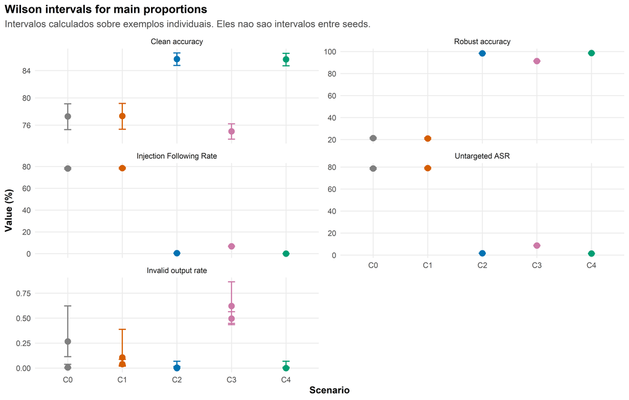

```r
wilson_plot_data <- wilson_proportions |>
  filter(
    metric %in% c(
      "clean_accuracy",
      "robust_accuracy",
      "injection_following_rate",
      "untargeted_asr",
      "invalid_output_rate"
    ),
    split_group %in% c("clean", "all_attacks")
  ) |>
  mutate(
    metric_label = factor(
      metric_label,
      levels = c(
        "Clean accuracy",
        "Robust accuracy",
        "Injection Following Rate",
        "Untargeted ASR",
        "Invalid output rate"
      )
    ),
    estimate_pct = estimate * 100,
    ci_low_pct = ci_low * 100,
    ci_high_pct = ci_high * 100
  )

p_wilson_main <- wilson_plot_data |>
  ggplot(aes(x = scenario_short, y = estimate_pct, color = scenario_short)) +
  geom_errorbar(
    aes(ymin = ci_low_pct, ymax = ci_high_pct),
    width = 0.13,
    linewidth = 0.7,
    show.legend = FALSE
  ) +
  geom_point(size = 3.2, show.legend = FALSE) +
  facet_wrap(~ metric_label, scales = "free_y", ncol = 2) +
  scale_color_manual(values = scenario_palette, drop = FALSE) +
  labs(
    title = "Wilson intervals for main proportions",
    subtitle = "Intervalos calculados sobre exemplos individuais. Eles nao sao intervalos entre seeds.",
    x = "Scenario",
    y = "Value (%)"
  ) +
  base_theme()

print(p_wilson_main)
```

```r
save_inf_figure(
  p_wilson_main,
  "01_wilson_main_proportions.png",
  width = 11,
  height = 7
)
```

# 8 Wilson intervals por tipo de ataque e por task

```r
wilson_by_attack_type <- proportion_events |>
  filter(split_group %in% c("seen", "unseen")) |>
  group_by(
    scenario_id,
    scenario_short,
    scenario_label,
    metric,
    metric_label,
    metric_group,
    direction,
    attack_type
  ) |>
  summarise(
    n = n(),
    k = sum(event_int),
    .groups = "drop"
  ) |>
  rowwise() |>
  mutate(wilson = list(wilson_ci(k, n, conf.level = CONF_LEVEL))) |>
  unnest(wilson) |>
  ungroup() |>
  sort_scenarios()

wilson_by_task <- proportion_events |>
  group_by(
    scenario_id,
    scenario_short,
    scenario_label,
    metric,
    metric_label,
    metric_group,
    direction,
    task_name
  ) |>
  summarise(
    n = n(),
    k = sum(event_int),
    .groups = "drop"
  ) |>
  rowwise() |>
  mutate(wilson = list(wilson_ci(k, n, conf.level = CONF_LEVEL))) |>
  unnest(wilson) |>
  ungroup() |>
  sort_scenarios()

write_inf_csv(wilson_by_attack_type, "05_wilson_by_attack_type_fraction.csv")
write_inf_csv(wilson_by_task, "06_wilson_by_task_fraction.csv")

wilson_by_attack_type |>
  filter(metric == "injection_following_rate") |>
  select(scenario_short, attack_type, n, k, estimate, ci_low, ci_high) |>
  mutate(across(c(estimate, ci_low, ci_high), ~ fmt_pct(.x))) |>
  head(30) |>
  knitr::kable(
    caption = "Tabela 5 - Wilson intervals da Injection Following Rate por tipo de ataque."
  )
```

Tabela 5 - Wilson intervals da Injection Following Rate por tipo de ataque.

| scenario_short | attack_type | n | k | estimate | ci_low | ci_high |
| --- | --- | --- | --- | --- | --- | --- |
| C0 | combine | 1876 | 1747 | 93.1% | 91.9% | 94.2% |
| C0 | combine_adaptive | 1876 | 1132 | 60.3% | 58.1% | 62.5% |
| C0 | escape | 1876 | 1660 | 88.5% | 87.0% | 89.9% |
| C0 | fake_comp | 1876 | 1565 | 83.4% | 81.7% | 85.0% |
| C0 | gcg | 1876 | 807 | 43.0% | 40.8% | 45.3% |
| C0 | gcg_adaptive | 1876 | 1612 | 85.9% | 84.3% | 87.4% |
| C0 | ignore | 1876 | 1525 | 81.3% | 79.5% | 83.0% |
| C0 | naive | 1876 | 1686 | 89.9% | 88.4% | 91.2% |
| C1 | combine | 1876 | 1836 | 97.9% | 97.1% | 98.4% |
| C1 | combine_adaptive | 1876 | 1427 | 76.1% | 74.1% | 77.9% |
| C1 | escape | 1876 | 1625 | 86.6% | 85.0% | 88.1% |
| C1 | fake_comp | 1876 | 1427 | 76.1% | 74.1% | 77.9% |
| C1 | gcg | 1876 | 872 | 46.5% | 44.2% | 48.7% |
| C1 | gcg_adaptive | 1876 | 1600 | 85.3% | 83.6% | 86.8% |
| C1 | ignore | 1876 | 1605 | 85.6% | 83.9% | 87.1% |
| C1 | naive | 1876 | 1392 | 74.2% | 72.2% | 76.1% |
| C2 | combine | 5628 | 9 | 0.2% | 0.1% | 0.3% |
| C2 | combine_adaptive | 5628 | 45 | 0.8% | 0.6% | 1.1% |
| C2 | escape | 5628 | 8 | 0.1% | 0.1% | 0.3% |
| C2 | fake_comp | 5628 | 8 | 0.1% | 0.1% | 0.3% |
| C2 | gcg | 5628 | 100 | 1.8% | 1.5% | 2.2% |
| C2 | gcg_adaptive | 5628 | 6 | 0.1% | 0.0% | 0.2% |
| C2 | ignore | 5628 | 11 | 0.2% | 0.1% | 0.3% |
| C2 | naive | 5628 | 7 | 0.1% | 0.1% | 0.3% |
| C3 | combine | 5628 | 438 | 7.8% | 7.1% | 8.5% |
| C3 | combine_adaptive | 5628 | 707 | 12.6% | 11.7% | 13.5% |
| C3 | escape | 5628 | 420 | 7.5% | 6.8% | 8.2% |
| C3 | fake_comp | 5628 | 333 | 5.9% | 5.3% | 6.6% |
| C3 | gcg | 5628 | 177 | 3.1% | 2.7% | 3.6% |
| C3 | gcg_adaptive | 5628 | 276 | 4.9% | 4.4% | 5.5% |

# 9 Teste binomial exato contra referencia C0

Este teste compara a proporcao observada em cada cenario contra a proporcao observada do C0 no mesmo split/metrica.

Importante: aqui o C0 e tratado como referencia fixa. Para comparacao pareada no mesmo exemplo, veja as secoes de bootstrap e teste pareado abaixo.

```r
c0_reference_proportions <- wilson_proportions |>
  filter(scenario_id == "c0_base") |>
  select(
    metric,
    split_group,
    c0_n = n,
    c0_k = k,
    c0_estimate = estimate
  )

exact_binomial_vs_c0 <- wilson_proportions |>
  filter(scenario_id != "c0_base") |>
  left_join(c0_reference_proportions, by = c("metric", "split_group")) |>
  mutate(
    alternative = if_else(direction == "higher", "greater", "less"),
    p_value = pmap_dbl(
      list(k, n, c0_estimate, alternative),
      exact_binom_p
    ),
    significant_05 = !is.na(p_value) & p_value < 0.05
  ) |>
  arrange(metric, split_group, p_value)

write_inf_csv(exact_binomial_vs_c0, "07_exact_binomial_vs_c0.csv")

exact_binomial_vs_c0 |>
  filter(
    metric %in% c("clean_accuracy", "robust_accuracy", "injection_following_rate", "invalid_output_rate"),
    split_group %in% c("clean", "all_attacks")
  ) |>
  select(
    scenario_short,
    metric_label,
    split_group,
    n,
    k,
    estimate,
    c0_estimate,
    alternative,
    p_value,
    significant_05
  ) |>
  mutate(
    estimate = fmt_pct(estimate),
    c0_estimate = fmt_pct(c0_estimate),
    p_value = scales::pvalue(p_value, accuracy = 0.001)
  ) |>
  knitr::kable(
    caption = "Tabela 6 - Teste binomial exato contra a proporcao do C0."
  )
```

Tabela 6 - Teste binomial exato contra a proporcao do C0.

| scenario_short | metric_label | split_group | n | k | estimate | c0_estimate | alternative | p_value | significant_05 |
| --- | --- | --- | --- | --- | --- | --- | --- | --- | --- |
| C2 | Clean accuracy | clean | 5628 | 4823 | 85.7% | 77.3% | greater | <0.001 | TRUE |
| C4 | Clean accuracy | clean | 5628 | 4820 | 85.6% | 77.3% | greater | <0.001 | TRUE |
| C1 | Clean accuracy | clean | 1876 | 1451 | 77.3% | 77.3% | greater | 0.491 | FALSE |
| C3 | Clean accuracy | clean | 5628 | 4226 | 75.1% | 77.3% | greater | >0.999 | FALSE |
| C2 | Injection Following Rate | all_attacks | 45024 | 194 | 0.4% | 78.2% | less | <0.001 | TRUE |
| C3 | Injection Following Rate | all_attacks | 45024 | 3055 | 6.8% | 78.2% | less | <0.001 | TRUE |
| C4 | Injection Following Rate | all_attacks | 45024 | 21 | 0.0% | 78.2% | less | <0.001 | TRUE |
| C1 | Injection Following Rate | all_attacks | 15008 | 11784 | 78.5% | 78.2% | less | 0.841 | FALSE |
| C2 | Invalid output rate | clean | 5628 | 0 | 0.0% | 0.3% | less | <0.001 | TRUE |
| C4 | Invalid output rate | clean | 5628 | 0 | 0.0% | 0.3% | less | <0.001 | TRUE |
| C1 | Invalid output rate | clean | 1876 | 2 | 0.1% | 0.3% | less | 0.124 | FALSE |
| C3 | Invalid output rate | clean | 5628 | 35 | 0.6% | 0.3% | less | >0.999 | FALSE |
| C4 | Invalid output rate | all_attacks | 45024 | 0 | 0.0% | 0.0% | less | 0.050 | TRUE |
| C2 | Invalid output rate | all_attacks | 45024 | 2 | 0.0% | 0.0% | less | 0.423 | FALSE |
| C1 | Invalid output rate | all_attacks | 15008 | 6 | 0.0% | 0.0% | less | >0.999 | FALSE |
| C3 | Invalid output rate | all_attacks | 45024 | 223 | 0.5% | 0.0% | less | >0.999 | FALSE |
| C2 | Robust accuracy | all_attacks | 45024 | 44290 | 98.4% | 21.3% | greater | <0.001 | TRUE |
| C3 | Robust accuracy | all_attacks | 45024 | 41110 | 91.3% | 21.3% | greater | <0.001 | TRUE |
| C4 | Robust accuracy | all_attacks | 45024 | 44394 | 98.6% | 21.3% | greater | <0.001 | TRUE |
| C1 | Robust accuracy | all_attacks | 15008 | 3148 | 21.0% | 21.3% | greater | 0.828 | FALSE |

# 10 Comparacao pareada contra C0

Esta secao usa `paired_vs_c0_rows.csv`, que ja contem as saidas do cenario avaliado e a saida correspondente do C0 no mesmo exemplo.

```r
paired_rows_path <- file.path(ERROR_TABLE_DIR, "paired_vs_c0_rows.csv")

if (!file.exists(paired_rows_path)) {
  paired_rows <- NULL
  cat("Arquivo paired_vs_c0_rows.csv nao encontrado. Secoes pareadas serao puladas.")
} else {
  paired_rows <- readr::read_csv(
    paired_rows_path,
    show_col_types = FALSE,
    col_select = any_of(c(
      "scenario_id",
      "scenario_label",
      "seed",
      "eval_split",
      "example_id",
      "example_key",
      "base_id",
      "task_name",
      "attack_type",
      "is_correct",
      "followed_attack",
      "is_invalid_output",
      "is_valid_output",
      "reference_is_correct",
      "reference_followed_attack",
      "reference_is_valid_output"
    ))
  ) |>
    add_scenario_info() |>
    mutate(
      seed = as.integer(seed),
      attack_type = ifelse(is.na(attack_type) | attack_type == "", "clean", as.character(attack_type)),
      task_name = as.character(task_name),
      eval_split = as.character(eval_split),
      is_attacked_split = eval_split %in% c("test_attacked_seen", "test_attacked_unseen"),
      is_correct = to_logical_safe(is_correct),
      followed_attack = to_logical_safe(followed_attack),
      is_invalid_output = to_logical_safe(is_invalid_output),
      is_valid_output = to_logical_safe(is_valid_output),
      reference_is_correct = to_logical_safe(reference_is_correct),
      reference_followed_attack = to_logical_safe(reference_followed_attack),
      reference_is_valid_output = to_logical_safe(reference_is_valid_output),
      reference_is_invalid_output = !reference_is_valid_output
    )

  paired_coverage <- paired_rows |>
    count(scenario_id, scenario_short, seed, eval_split, name = "paired_examples") |>
    sort_scenarios()

  write_inf_csv(paired_coverage, "08_paired_rows_coverage.csv")

  paired_coverage |>
    knitr::kable(
      caption = "Tabela 7 - Cobertura dos exemplos pareados contra C0."
    )
}
```

Tabela 7 - Cobertura dos exemplos pareados contra C0.

| scenario_id | scenario_short | seed | eval_split | paired_examples |
| --- | --- | --- | --- | --- |
| c1_struq_format_only | C1 | 42 | test_attacked_seen | 9380 |
| c1_struq_format_only | C1 | 42 | test_attacked_unseen | 5628 |
| c1_struq_format_only | C1 | 42 | test_clean | 1876 |
| c2_struq_sft | C2 | 42 | test_attacked_seen | 9380 |
| c2_struq_sft | C2 | 42 | test_attacked_unseen | 5628 |
| c2_struq_sft | C2 | 42 | test_clean | 1876 |
| c2_struq_sft | C2 | 123 | test_attacked_seen | 9380 |
| c2_struq_sft | C2 | 123 | test_attacked_unseen | 5628 |
| c2_struq_sft | C2 | 123 | test_clean | 1876 |
| c2_struq_sft | C2 | 2026 | test_attacked_seen | 9380 |
| c2_struq_sft | C2 | 2026 | test_attacked_unseen | 5628 |
| c2_struq_sft | C2 | 2026 | test_clean | 1876 |
| c3_secalign_dpo | C3 | 42 | test_attacked_seen | 9380 |
| c3_secalign_dpo | C3 | 42 | test_attacked_unseen | 5628 |
| c3_secalign_dpo | C3 | 42 | test_clean | 1876 |
| c3_secalign_dpo | C3 | 123 | test_attacked_seen | 9380 |
| c3_secalign_dpo | C3 | 123 | test_attacked_unseen | 5628 |
| c3_secalign_dpo | C3 | 123 | test_clean | 1876 |
| c3_secalign_dpo | C3 | 2026 | test_attacked_seen | 9380 |
| c3_secalign_dpo | C3 | 2026 | test_attacked_unseen | 5628 |
| c3_secalign_dpo | C3 | 2026 | test_clean | 1876 |
| c4_ih_sft | C4 | 42 | test_attacked_seen | 9380 |
| c4_ih_sft | C4 | 42 | test_attacked_unseen | 5628 |
| c4_ih_sft | C4 | 42 | test_clean | 1876 |
| c4_ih_sft | C4 | 123 | test_attacked_seen | 9380 |
| c4_ih_sft | C4 | 123 | test_attacked_unseen | 5628 |
| c4_ih_sft | C4 | 123 | test_clean | 1876 |
| c4_ih_sft | C4 | 2026 | test_attacked_seen | 9380 |
| c4_ih_sft | C4 | 2026 | test_attacked_unseen | 5628 |
| c4_ih_sft | C4 | 2026 | test_clean | 1876 |

```r
if (!is.null(paired_rows)) {
  paired_events <- bind_rows(
    paired_rows |>
      filter(eval_split == "test_clean") |>
      transmute(
        scenario_id,
        scenario_short,
        scenario_label,
        seed,
        eval_split,
        task_name,
        attack_type,
        metric = "clean_accuracy_delta_vs_c0",
        metric_label = "Clean accuracy delta vs C0",
        direction = "higher",
        event_defense = is_correct,
        event_reference = reference_is_correct
      ),

    paired_rows |>
      filter(is_attacked_split) |>
      transmute(
        scenario_id,
        scenario_short,
        scenario_label,
        seed,
        eval_split,
        task_name,
        attack_type,
        metric = "robust_accuracy_delta_vs_c0",
        metric_label = "Robust accuracy delta vs C0",
        direction = "higher",
        event_defense = is_correct,
        event_reference = reference_is_correct
      ),

    paired_rows |>
      filter(is_attacked_split) |>
      transmute(
        scenario_id,
        scenario_short,
        scenario_label,
        seed,
        eval_split,
        task_name,
        attack_type,
        metric = "injection_following_rate_delta_vs_c0",
        metric_label = "Injection Following Rate delta vs C0",
        direction = "lower",
        event_defense = followed_attack,
        event_reference = reference_followed_attack
      ),

    paired_rows |>
      transmute(
        scenario_id,
        scenario_short,
        scenario_label,
        seed,
        eval_split,
        task_name,
        attack_type,
        metric = "invalid_output_rate_delta_vs_c0",
        metric_label = "Invalid output rate delta vs C0",
        direction = "lower",
        event_defense = is_invalid_output,
        event_reference = reference_is_invalid_output
      )
  ) |>
    filter(!is.na(event_defense), !is.na(event_reference)) |>
    mutate(
      event_defense_int = as.integer(event_defense),
      event_reference_int = as.integer(event_reference),
      raw_delta = event_defense_int - event_reference_int,
      direction_adjusted_delta = if_else(direction == "higher", raw_delta, -raw_delta),
      stratum = paste(seed, eval_split, task_name, attack_type, sep = "__")
    )

  write_inf_csv(paired_events, "09_paired_events_long.csv")

  paired_events |>
    count(metric_label, eval_split, scenario_short, name = "n_pairs") |>
    head(40) |>
    knitr::kable(
      caption = "Tabela 8 - Eventos pareados construidos para comparacao contra C0."
    )
}
```

Tabela 8 - Eventos pareados construidos para comparacao contra C0.

| metric_label | eval_split | scenario_short | n_pairs |
| --- | --- | --- | --- |
| Clean accuracy delta vs C0 | test_clean | C1 | 1876 |
| Clean accuracy delta vs C0 | test_clean | C2 | 5628 |
| Clean accuracy delta vs C0 | test_clean | C3 | 5628 |
| Clean accuracy delta vs C0 | test_clean | C4 | 5628 |
| Injection Following Rate delta vs C0 | test_attacked_seen | C1 | 9380 |
| Injection Following Rate delta vs C0 | test_attacked_seen | C2 | 28140 |
| Injection Following Rate delta vs C0 | test_attacked_seen | C3 | 28140 |
| Injection Following Rate delta vs C0 | test_attacked_seen | C4 | 28140 |
| Injection Following Rate delta vs C0 | test_attacked_unseen | C1 | 5628 |
| Injection Following Rate delta vs C0 | test_attacked_unseen | C2 | 16884 |
| Injection Following Rate delta vs C0 | test_attacked_unseen | C3 | 16884 |
| Injection Following Rate delta vs C0 | test_attacked_unseen | C4 | 16884 |
| Invalid output rate delta vs C0 | test_attacked_seen | C1 | 9380 |
| Invalid output rate delta vs C0 | test_attacked_seen | C2 | 28140 |
| Invalid output rate delta vs C0 | test_attacked_seen | C3 | 28140 |
| Invalid output rate delta vs C0 | test_attacked_seen | C4 | 28140 |
| Invalid output rate delta vs C0 | test_attacked_unseen | C1 | 5628 |
| Invalid output rate delta vs C0 | test_attacked_unseen | C2 | 16884 |
| Invalid output rate delta vs C0 | test_attacked_unseen | C3 | 16884 |
| Invalid output rate delta vs C0 | test_attacked_unseen | C4 | 16884 |
| Invalid output rate delta vs C0 | test_clean | C1 | 1876 |
| Invalid output rate delta vs C0 | test_clean | C2 | 5628 |
| Invalid output rate delta vs C0 | test_clean | C3 | 5628 |
| Invalid output rate delta vs C0 | test_clean | C4 | 5628 |
| Robust accuracy delta vs C0 | test_attacked_seen | C1 | 9380 |
| Robust accuracy delta vs C0 | test_attacked_seen | C2 | 28140 |
| Robust accuracy delta vs C0 | test_attacked_seen | C3 | 28140 |
| Robust accuracy delta vs C0 | test_attacked_seen | C4 | 28140 |
| Robust accuracy delta vs C0 | test_attacked_unseen | C1 | 5628 |
| Robust accuracy delta vs C0 | test_attacked_unseen | C2 | 16884 |
| Robust accuracy delta vs C0 | test_attacked_unseen | C3 | 16884 |
| Robust accuracy delta vs C0 | test_attacked_unseen | C4 | 16884 |

# 11 Bootstrap pareado

O bootstrap reamostra os pares com reposicao. Quando possivel, a reamostragem preserva os estratos `seed`, `eval_split`, `task_name` e `attack_type`.

```r
bootstrap_stratified_mean <- function(values, strata, B = 500) {
  values <- as.numeric(values)
  strata <- as.character(strata)

  valid <- !is.na(values) & !is.na(strata)

  values <- values[valid]
  strata <- strata[valid]

  if (length(values) == 0) {
    return(rep(NA_real_, B))
  }

  split_values <- split(values, strata)

  replicate(
    B,
    {
      sampled <- unlist(
        lapply(
          split_values,
          function(x) {
            sample(x, size = length(x), replace = TRUE)
          }
        ),
        use.names = FALSE
      )

      mean(sampled, na.rm = TRUE)
    }
  )
}

summarise_bootstrap_delta <- function(df, B = N_BOOTSTRAP) {
  raw_boot <- bootstrap_stratified_mean(df$raw_delta, df$stratum, B = B)
  adjusted_boot <- bootstrap_stratified_mean(df$direction_adjusted_delta, df$stratum, B = B)

  tibble(
    n_pairs = nrow(df),
    n_strata = n_distinct(df$stratum),
    mean_raw_delta = mean(df$raw_delta, na.rm = TRUE),
    mean_direction_adjusted_delta = mean(df$direction_adjusted_delta, na.rm = TRUE),
    boot_raw_ci_low = as.numeric(quantile(raw_boot, 0.025, na.rm = TRUE)),
    boot_raw_ci_high = as.numeric(quantile(raw_boot, 0.975, na.rm = TRUE)),
    boot_adjusted_ci_low = as.numeric(quantile(adjusted_boot, 0.025, na.rm = TRUE)),
    boot_adjusted_ci_high = as.numeric(quantile(adjusted_boot, 0.975, na.rm = TRUE))
  )
}
```

```r
if (exists("paired_events")) {
  paired_bootstrap <- paired_events |>
    group_by(
      scenario_id,
      scenario_short,
      scenario_label,
      eval_split,
      metric,
      metric_label,
      direction
    ) |>
    group_modify(~ summarise_bootstrap_delta(.x, B = N_BOOTSTRAP)) |>
    ungroup() |>
    sort_scenarios() |>
    mutate(
      improvement_direction = if_else(
        direction == "higher",
        "Positive adjusted delta means higher than C0.",
        "Positive adjusted delta means lower than C0."
      )
    )

  write_inf_csv(paired_bootstrap, "10_paired_bootstrap_delta_vs_c0_fraction.csv")

  paired_bootstrap_percent <- paired_bootstrap |>
    mutate(
      across(
        c(
          mean_raw_delta,
          mean_direction_adjusted_delta,
          boot_raw_ci_low,
          boot_raw_ci_high,
          boot_adjusted_ci_low,
          boot_adjusted_ci_high
        ),
        ~ .x * 100
      )
    )

  write_inf_csv(paired_bootstrap_percent, "10_paired_bootstrap_delta_vs_c0_percent.csv")

  paired_bootstrap |>
    select(
      scenario_short,
      eval_split,
      metric_label,
      n_pairs,
      n_strata,
      mean_raw_delta,
      boot_raw_ci_low,
      boot_raw_ci_high,
      mean_direction_adjusted_delta,
      boot_adjusted_ci_low,
      boot_adjusted_ci_high
    ) |>
    mutate(
      across(
        c(
          mean_raw_delta,
          boot_raw_ci_low,
          boot_raw_ci_high,
          mean_direction_adjusted_delta,
          boot_adjusted_ci_low,
          boot_adjusted_ci_high
        ),
        ~ fmt_pct(.x)
      )
    ) |>
    head(40) |>
    knitr::kable(
      caption = "Tabela 9 - Bootstrap pareado dos deltas contra C0."
    )
}
```

Tabela 9 - Bootstrap pareado dos deltas contra C0.

| scenario_short | eval_split | metric_label | n_pairs | n_strata | mean_raw_delta | boot_raw_ci_low | boot_raw_ci_high | mean_direction_adjusted_delta | boot_adjusted_ci_low | boot_adjusted_ci_high |
| --- | --- | --- | --- | --- | --- | --- | --- | --- | --- | --- |
| C1 | test_attacked_seen | Injection Following Rate delta vs C0 | 9380 | 35 | -5.1% | -5.8% | -4.5% | 5.1% | 4.5% | 5.8% |
| C1 | test_attacked_seen | Invalid output rate delta vs C0 | 9380 | 35 | 0.0% | 0.0% | 0.1% | 0.0% | -0.1% | 0.0% |
| C1 | test_attacked_seen | Robust accuracy delta vs C0 | 9380 | 35 | 5.1% | 4.3% | 5.8% | 5.1% | 4.5% | 5.7% |
| C1 | test_attacked_unseen | Injection Following Rate delta vs C0 | 5628 | 21 | 8.2% | 7.1% | 9.4% | -8.2% | -9.3% | -7.1% |
| C1 | test_attacked_unseen | Invalid output rate delta vs C0 | 5628 | 21 | 0.0% | 0.0% | 0.1% | 0.0% | -0.1% | 0.0% |
| C1 | test_attacked_unseen | Robust accuracy delta vs C0 | 5628 | 21 | -8.0% | -9.2% | -6.9% | -8.0% | -9.3% | -6.9% |
| C1 | test_clean | Clean accuracy delta vs C0 | 1876 | 7 | 0.1% | -1.4% | 1.4% | 0.1% | -1.5% | 1.5% |
| C1 | test_clean | Invalid output rate delta vs C0 | 1876 | 7 | -0.2% | -0.4% | 0.1% | 0.2% | -0.1% | 0.4% |
| C2 | test_attacked_seen | Injection Following Rate delta vs C0 | 28140 | 105 | -89.0% | -89.4% | -88.7% | 89.0% | 88.7% | 89.4% |
| C2 | test_attacked_seen | Invalid output rate delta vs C0 | 28140 | 105 | 0.0% | 0.0% | 0.0% | 0.0% | 0.0% | 0.0% |
| C2 | test_attacked_seen | Robust accuracy delta vs C0 | 28140 | 105 | 88.3% | 87.9% | 88.7% | 88.3% | 87.9% | 88.6% |
| C2 | test_attacked_unseen | Injection Following Rate delta vs C0 | 16884 | 63 | -60.1% | -60.9% | -59.6% | 60.1% | 59.4% | 60.8% |
| C2 | test_attacked_unseen | Invalid output rate delta vs C0 | 16884 | 63 | 0.0% | 0.0% | 0.0% | 0.0% | 0.0% | 0.0% |
| C2 | test_attacked_unseen | Robust accuracy delta vs C0 | 16884 | 63 | 59.7% | 59.0% | 60.3% | 59.7% | 59.0% | 60.4% |
| C2 | test_clean | Clean accuracy delta vs C0 | 5628 | 21 | 8.4% | 7.5% | 9.5% | 8.4% | 7.3% | 9.4% |
| C2 | test_clean | Invalid output rate delta vs C0 | 5628 | 21 | -0.3% | -0.4% | -0.1% | 0.3% | 0.1% | 0.4% |
| C3 | test_attacked_seen | Injection Following Rate delta vs C0 | 28140 | 105 | -82.4% | -82.9% | -82.1% | 82.4% | 82.0% | 82.9% |
| C3 | test_attacked_seen | Invalid output rate delta vs C0 | 28140 | 105 | 0.6% | 0.6% | 0.7% | -0.6% | -0.7% | -0.5% |
| C3 | test_attacked_seen | Robust accuracy delta vs C0 | 28140 | 105 | 80.8% | 80.4% | 81.2% | 80.8% | 80.4% | 81.2% |
| C3 | test_attacked_unseen | Injection Following Rate delta vs C0 | 16884 | 63 | -54.2% | -55.0% | -53.5% | 54.2% | 53.5% | 54.8% |
| C3 | test_attacked_unseen | Invalid output rate delta vs C0 | 16884 | 63 | 0.3% | 0.2% | 0.3% | -0.3% | -0.4% | -0.2% |
| C3 | test_attacked_unseen | Robust accuracy delta vs C0 | 16884 | 63 | 53.3% | 52.6% | 54.0% | 53.3% | 52.6% | 54.0% |
| C3 | test_clean | Clean accuracy delta vs C0 | 5628 | 21 | -2.2% | -3.4% | -1.1% | -2.2% | -3.3% | -1.1% |
| C3 | test_clean | Invalid output rate delta vs C0 | 5628 | 21 | 0.4% | 0.2% | 0.5% | -0.4% | -0.5% | -0.2% |
| C4 | test_attacked_seen | Injection Following Rate delta vs C0 | 28140 | 105 | -89.2% | -89.5% | -88.8% | 89.2% | 88.8% | 89.5% |
| C4 | test_attacked_seen | Invalid output rate delta vs C0 | 28140 | 105 | 0.0% | 0.0% | 0.0% | 0.0% | 0.0% | 0.0% |
| C4 | test_attacked_seen | Robust accuracy delta vs C0 | 28140 | 105 | 88.2% | 87.8% | 88.6% | 88.2% | 87.9% | 88.6% |
| C4 | test_attacked_unseen | Injection Following Rate delta vs C0 | 16884 | 63 | -60.9% | -61.5% | -60.2% | 60.9% | 60.3% | 61.6% |
| C4 | test_attacked_unseen | Invalid output rate delta vs C0 | 16884 | 63 | 0.0% | 0.0% | 0.0% | 0.0% | 0.0% | 0.0% |
| C4 | test_attacked_unseen | Robust accuracy delta vs C0 | 16884 | 63 | 60.4% | 59.7% | 61.1% | 60.4% | 59.6% | 61.1% |
| C4 | test_clean | Clean accuracy delta vs C0 | 5628 | 21 | 8.4% | 7.3% | 9.3% | 8.4% | 7.4% | 9.5% |
| C4 | test_clean | Invalid output rate delta vs C0 | 5628 | 21 | -0.3% | -0.4% | -0.1% | 0.3% | 0.2% | 0.4% |

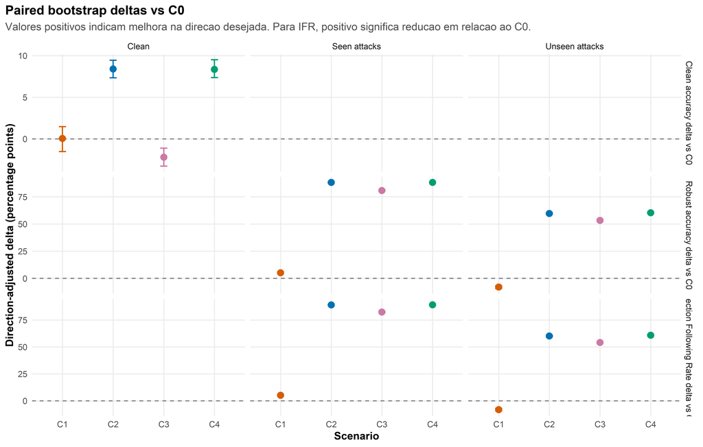

```r
if (exists("paired_bootstrap")) {
  bootstrap_plot_data <- paired_bootstrap |>
    filter(metric %in% c(
      "clean_accuracy_delta_vs_c0",
      "robust_accuracy_delta_vs_c0",
      "injection_following_rate_delta_vs_c0"
    )) |>
    mutate(
      metric_label = factor(
        metric_label,
        levels = c(
          "Clean accuracy delta vs C0",
          "Robust accuracy delta vs C0",
          "Injection Following Rate delta vs C0"
        )
      ),
      mean_adj_pct = mean_direction_adjusted_delta * 100,
      low_adj_pct = boot_adjusted_ci_low * 100,
      high_adj_pct = boot_adjusted_ci_high * 100,
      eval_split_label = case_when(
        eval_split == "test_clean" ~ "Clean",
        eval_split == "test_attacked_seen" ~ "Seen attacks",
        eval_split == "test_attacked_unseen" ~ "Unseen attacks",
        TRUE ~ eval_split
      )
    )

  p_bootstrap_delta <- bootstrap_plot_data |>
    ggplot(aes(x = scenario_short, y = mean_adj_pct, color = scenario_short)) +
    geom_hline(yintercept = 0, linetype = "dashed", color = "grey45") +
    geom_errorbar(
      aes(ymin = low_adj_pct, ymax = high_adj_pct),
      width = 0.14,
      linewidth = 0.7,
      show.legend = FALSE
    ) +
    geom_point(size = 3.1, show.legend = FALSE) +
    facet_grid(metric_label ~ eval_split_label, scales = "free_y") +
    scale_color_manual(values = scenario_palette, drop = FALSE) +
    labs(
      title = "Paired bootstrap deltas vs C0",
      subtitle = "Valores positivos indicam melhora na direcao desejada. Para IFR, positivo significa reducao em relacao ao C0.",
      x = "Scenario",
      y = "Direction-adjusted delta (percentage points)"
    ) +
    base_theme()

  print(p_bootstrap_delta)

  save_inf_figure(
    p_bootstrap_delta,
    "02_paired_bootstrap_delta_vs_c0.png",
    width = 11,
    height = 7
  )
}
```

# 12 Teste binomial pareado em pares discordantes

Este teste considera apenas pares discordantes:

- para metricas em que maior e melhor, conta casos em que a defesa acerta e C0 erra contra casos em que a defesa erra e C0 acerta;
- para metricas em que menor e melhor, conta casos em que a defesa evita o evento e C0 apresenta o evento contra o inverso.

A hipotese nula e que, entre pares discordantes, melhora e piora sao igualmente provaveis.

```r
if (exists("paired_events")) {
  paired_sign_test <- paired_events |>
    mutate(
      defense_better = case_when(
        direction == "higher" & event_defense_int == 1 & event_reference_int == 0 ~ TRUE,
        direction == "lower" & event_defense_int == 0 & event_reference_int == 1 ~ TRUE,
        TRUE ~ FALSE
      ),
      defense_worse = case_when(
        direction == "higher" & event_defense_int == 0 & event_reference_int == 1 ~ TRUE,
        direction == "lower" & event_defense_int == 1 & event_reference_int == 0 ~ TRUE,
        TRUE ~ FALSE
      )
    ) |>
    group_by(
      scenario_id,
      scenario_short,
      scenario_label,
      eval_split,
      metric,
      metric_label,
      direction
    ) |>
    summarise(
      n_pairs = n(),
      better = sum(defense_better, na.rm = TRUE),
      worse = sum(defense_worse, na.rm = TRUE),
      discordant_pairs = better + worse,
      better_rate_among_discordant = if_else(discordant_pairs > 0, better / discordant_pairs, NA_real_),
      p_value = map2_dbl(
        better,
        discordant_pairs,
        ~ paired_binom_p(.x, .y, alternative = "greater")
      ),
      significant_05 = !is.na(p_value) & p_value < 0.05,
      .groups = "drop"
    ) |>
    sort_scenarios()

  write_inf_csv(paired_sign_test, "11_paired_binomial_sign_test_vs_c0.csv")

  paired_sign_test |>
    select(
      scenario_short,
      eval_split,
      metric_label,
      n_pairs,
      better,
      worse,
      discordant_pairs,
      better_rate_among_discordant,
      p_value,
      significant_05
    ) |>
    mutate(
      better_rate_among_discordant = fmt_pct(better_rate_among_discordant),
      p_value = scales::pvalue(p_value, accuracy = 0.001)
    ) |>
    head(50) |>
    knitr::kable(
      caption = "Tabela 10 - Teste binomial pareado sobre pares discordantes contra C0."
    )
}
```

Tabela 10 - Teste binomial pareado sobre pares discordantes contra C0.

| scenario_short | eval_split | metric_label | n_pairs | better | worse | discordant_pairs | better_rate_among_discordant | p_value | significant_05 |
| --- | --- | --- | --- | --- | --- | --- | --- | --- | --- |
| C1 | test_attacked_seen | Injection Following Rate delta vs C0 | 9380 | 921 | 441 | 1362 | 67.6% | <0.001 | TRUE |
| C1 | test_attacked_seen | Invalid output rate delta vs C0 | 9380 | 0 | 4 | 4 | 0.0% | >0.999 | FALSE |
| C1 | test_attacked_seen | Robust accuracy delta vs C0 | 9380 | 908 | 431 | 1339 | 67.8% | <0.001 | TRUE |
| C1 | test_attacked_unseen | Injection Following Rate delta vs C0 | 5628 | 445 | 909 | 1354 | 32.9% | >0.999 | FALSE |
| C1 | test_attacked_unseen | Invalid output rate delta vs C0 | 5628 | 0 | 2 | 2 | 0.0% | >0.999 | FALSE |
| C1 | test_attacked_unseen | Robust accuracy delta vs C0 | 5628 | 432 | 885 | 1317 | 32.8% | >0.999 | FALSE |
| C1 | test_clean | Clean accuracy delta vs C0 | 1876 | 109 | 108 | 217 | 50.2% | 0.500 | FALSE |
| C1 | test_clean | Invalid output rate delta vs C0 | 1876 | 4 | 1 | 5 | 80.0% | 0.187 | FALSE |
| C2 | test_attacked_seen | Injection Following Rate delta vs C0 | 28140 | 25054 | 2 | 25056 | 100.0% | <0.001 | TRUE |
| C2 | test_attacked_seen | Invalid output rate delta vs C0 | 28140 | 0 | 2 | 2 | 0.0% | >0.999 | FALSE |
| C2 | test_attacked_seen | Robust accuracy delta vs C0 | 28140 | 24874 | 31 | 24905 | 99.9% | <0.001 | TRUE |
| C2 | test_attacked_unseen | Injection Following Rate delta vs C0 | 16884 | 10172 | 18 | 10190 | 99.8% | <0.001 | TRUE |
| C2 | test_attacked_unseen | Invalid output rate delta vs C0 | 16884 | 0 | 0 | 0 | - | - | FALSE |
| C2 | test_attacked_unseen | Robust accuracy delta vs C0 | 16884 | 10101 | 26 | 10127 | 99.7% | <0.001 | TRUE |
| C2 | test_clean | Clean accuracy delta vs C0 | 5628 | 736 | 263 | 999 | 73.7% | <0.001 | TRUE |
| C2 | test_clean | Invalid output rate delta vs C0 | 5628 | 15 | 0 | 15 | 100.0% | <0.001 | TRUE |
| C3 | test_attacked_seen | Injection Following Rate delta vs C0 | 28140 | 23241 | 41 | 23282 | 99.8% | <0.001 | TRUE |
| C3 | test_attacked_seen | Invalid output rate delta vs C0 | 28140 | 0 | 177 | 177 | 0.0% | >0.999 | FALSE |
| C3 | test_attacked_seen | Robust accuracy delta vs C0 | 28140 | 22794 | 60 | 22854 | 99.7% | <0.001 | TRUE |
| C3 | test_attacked_unseen | Injection Following Rate delta vs C0 | 16884 | 9301 | 156 | 9457 | 98.4% | <0.001 | TRUE |
| C3 | test_attacked_unseen | Invalid output rate delta vs C0 | 16884 | 0 | 46 | 46 | 0.0% | >0.999 | FALSE |
| C3 | test_attacked_unseen | Robust accuracy delta vs C0 | 16884 | 9169 | 165 | 9334 | 98.2% | <0.001 | TRUE |
| C3 | test_clean | Clean accuracy delta vs C0 | 5628 | 489 | 613 | 1102 | 44.4% | >0.999 | FALSE |
| C3 | test_clean | Invalid output rate delta vs C0 | 5628 | 3 | 23 | 26 | 11.5% | >0.999 | FALSE |
| C4 | test_attacked_seen | Injection Following Rate delta vs C0 | 28140 | 25095 | 0 | 25095 | 100.0% | <0.001 | TRUE |
| C4 | test_attacked_seen | Invalid output rate delta vs C0 | 28140 | 0 | 0 | 0 | - | - | FALSE |
| C4 | test_attacked_seen | Robust accuracy delta vs C0 | 28140 | 24876 | 45 | 24921 | 99.8% | <0.001 | TRUE |
| C4 | test_attacked_unseen | Injection Following Rate delta vs C0 | 16884 | 10286 | 2 | 10288 | 100.0% | <0.001 | TRUE |
| C4 | test_attacked_unseen | Invalid output rate delta vs C0 | 16884 | 0 | 0 | 0 | - | - | FALSE |
| C4 | test_attacked_unseen | Robust accuracy delta vs C0 | 16884 | 10209 | 18 | 10227 | 99.8% | <0.001 | TRUE |
| C4 | test_clean | Clean accuracy delta vs C0 | 5628 | 735 | 265 | 1000 | 73.5% | <0.001 | TRUE |
| C4 | test_clean | Invalid output rate delta vs C0 | 5628 | 15 | 0 | 15 | 100.0% | <0.001 | TRUE |

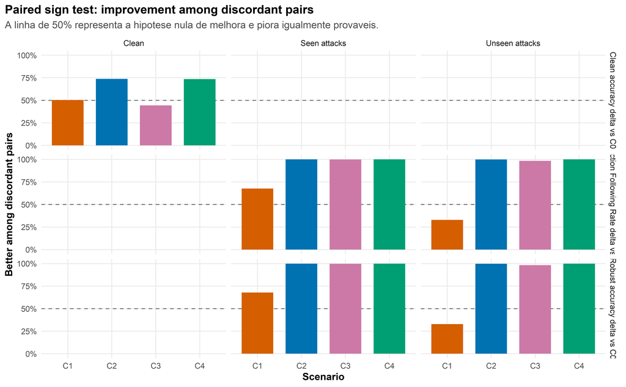

```r
if (exists("paired_sign_test")) {
  sign_plot_data <- paired_sign_test |>
    filter(metric %in% c(
      "clean_accuracy_delta_vs_c0",
      "robust_accuracy_delta_vs_c0",
      "injection_following_rate_delta_vs_c0"
    )) |>
    mutate(
      eval_split_label = case_when(
        eval_split == "test_clean" ~ "Clean",
        eval_split == "test_attacked_seen" ~ "Seen attacks",
        eval_split == "test_attacked_unseen" ~ "Unseen attacks",
        TRUE ~ eval_split
      )
    )

  p_sign_test <- sign_plot_data |>
    ggplot(aes(x = scenario_short, y = better_rate_among_discordant, fill = scenario_short)) +
    geom_hline(yintercept = 0.5, linetype = "dashed", color = "grey45") +
    geom_col(width = 0.72, show.legend = FALSE) +
    facet_grid(metric_label ~ eval_split_label) +
    scale_fill_manual(values = scenario_palette, drop = FALSE) +
    scale_y_continuous(labels = scales::percent_format(accuracy = 1), limits = c(0, 1)) +
    labs(
      title = "Paired sign test: improvement among discordant pairs",
      subtitle = "A linha de 50% representa a hipotese nula de melhora e piora igualmente provaveis.",
      x = "Scenario",
      y = "Better among discordant pairs"
    ) +
    base_theme()

  print(p_sign_test)

  save_inf_figure(
    p_sign_test,
    "03_paired_sign_test_discordant_pairs.png",
    width = 10.5,
    height = 6.5
  )
}
```

# 13 Resumo executivo

```r
executive_summary <- list(
  wilson_main = wilson_proportions |>
    filter(
      metric %in% c("clean_accuracy", "robust_accuracy", "injection_following_rate", "invalid_output_rate"),
      split_group %in% c("clean", "all_attacks")
    ) |>
    select(scenario_short, metric_label, split_group, n, estimate, ci_low, ci_high),

  exact_binomial_main = exact_binomial_vs_c0 |>
    filter(
      metric %in% c("clean_accuracy", "robust_accuracy", "injection_following_rate", "invalid_output_rate"),
      split_group %in% c("clean", "all_attacks")
    ) |>
    select(scenario_short, metric_label, split_group, estimate, c0_estimate, p_value, significant_05)
)

write_inf_csv(executive_summary$wilson_main, "12_executive_wilson_main_fraction.csv")
write_inf_csv(executive_summary$exact_binomial_main, "13_executive_exact_binomial_main.csv")

if (exists("paired_bootstrap")) {
  write_inf_csv(
    paired_bootstrap |>
      filter(metric %in% c(
        "clean_accuracy_delta_vs_c0",
        "robust_accuracy_delta_vs_c0",
        "injection_following_rate_delta_vs_c0"
      )),
    "14_executive_paired_bootstrap_main.csv"
  )
}

if (exists("paired_sign_test")) {
  write_inf_csv(
    paired_sign_test |>
      filter(metric %in% c(
        "clean_accuracy_delta_vs_c0",
        "robust_accuracy_delta_vs_c0",
        "injection_following_rate_delta_vs_c0"
      )),
    "15_executive_paired_sign_test_main.csv"
  )
}

cat("Resumo executivo salvo em tables/proportion_and_paired_inference/.\n")
```

```
## Resumo executivo salvo em tables/proportion_and_paired_inference/.
```

# 14 Interpretacao metodologica

```r
cat("
## Como ler este Rmd

### Wilson intervals

Os Wilson intervals resumem incerteza de proporcoes binarias, como accuracy, robust accuracy, Injection Following Rate e invalid output rate. Eles sao preferiveis ao intervalo normal simples, especialmente quando a proporcao esta proxima de 0 ou 1.

### Teste binomial exato contra C0

O teste binomial exato compara a taxa observada contra a taxa de referencia do C0. Ele e util como diagnostico, mas trata o C0 como proporcao fixa. Para comparacao no mesmo exemplo, use os resultados pareados.

### Bootstrap pareado

O bootstrap pareado compara o cenario defendido com C0 no mesmo exemplo. Valores positivos no delta ajustado indicam melhora na direcao desejada. Para Injection Following Rate, isso significa reducao em relacao ao C0.

### Teste binomial pareado

O teste pareado considera apenas pares discordantes. Ele pergunta se a quantidade de pares em que a defesa melhora C0 e maior do que a quantidade de pares em que ela piora C0.
")
```

## 14.1 Como ler este Rmd

### 14.1.1 Wilson intervals

Os Wilson intervals resumem incerteza de proporcoes binarias, como accuracy, robust accuracy, Injection Following Rate e invalid output rate. Eles sao preferiveis ao intervalo normal simples, especialmente quando a proporcao esta proxima de 0 ou 1.

### 14.1.2 Teste binomial exato contra C0

O teste binomial exato compara a taxa observada contra a taxa de referencia do C0. Ele e util como diagnostico, mas trata o C0 como proporcao fixa. Para comparacao no mesmo exemplo, use os resultados pareados.

### 14.1.3 Bootstrap pareado

O bootstrap pareado compara o cenario defendido com C0 no mesmo exemplo. Valores positivos no delta ajustado indicam melhora na direcao desejada. Para Injection Following Rate, isso significa reducao em relacao ao C0.

### 14.1.4 Teste binomial pareado

O teste pareado considera apenas pares discordantes. Ele pergunta se a quantidade de pares em que a defesa melhora C0 e maior do que a quantidade de pares em que ela piora C0.

# 15 Arquivos gerados

Este Rmd salva tabelas em:

```
tables/proportion_and_paired_inference/
```

e figuras em:

```
figures/proportion_and_paired_inference/
```

Arquivos principais:

```
04_wilson_proportions_fraction.csv
04_wilson_proportions_percent.csv
05_wilson_by_attack_type_fraction.csv
06_wilson_by_task_fraction.csv
07_exact_binomial_vs_c0.csv
10_paired_bootstrap_delta_vs_c0_fraction.csv
10_paired_bootstrap_delta_vs_c0_percent.csv
11_paired_binomial_sign_test_vs_c0.csv

01_wilson_main_proportions.png
02_paired_bootstrap_delta_vs_c0.png
03_paired_sign_test_discordant_pairs.png
```